# Algoritmos para datos faltantes

Hemos visto modelos probabilísticos donde la inclusión de variables auxiliares latentes, interpretadas como datos faltantes, son de gran ayuda para poder trabajar con el modelo en cuestión. Por ejemplo un modelo de mezcla en el cual tenemos observaciones para las cuales no sabemos a que componente de la mezcla pertenecen éstas. En lo siguiente consideramos variables observables $X$ y variables de observación faltante $X^f$. Trabajaremos en el contexto de estimación puntual para $\theta$ determinando un modelo probabilístico $\left\{P_\theta,\, \theta\in\Theta \right\}$.

En un contexto frecuentista para un modelo probabilístico determinado por funciones de densidad de probabilidad $f_\theta$ puede que sea difícil hallar el estimador máximo verosimil asociado a la verosimilitud

$$ L(\theta;\pmb{x}) = \prod_{i=1}^n f_\theta(x_i) $$

mientras que es más sencillo maximizar

$$ L^c(\theta;\pmb{x},\pmb{x}^f) = \prod_{i=1}^n f^{c}_\theta(x_i,x_i^f) $$

donde $f^c$ es la densidad completada de $(X,X^f)$. En tales casos usualmente se puede implementar el siguiente esquema iterativo para encontrar el estimador máximo verosimil asociado a $L$.

### Algoritmo E-M (Esperanza-Maximización)

1) Elija un valor incial $\hat{\theta}^{(0)}$ y tome $k=1$.

2) Paso E (esperanza): calcule $$Q\left( \theta\, \Big| \,\hat{\theta}^{(k-1)}\right)=\mathbb{E}_{\hat{\theta}^{(k-1)}}\left[ \log\left( L^c(\theta; \pmb{X},\pmb{X}^f) \right)\, \Big| \, \pmb{X}=\pmb{x} \right]$$

3) Paso M (maximización): tome $$\hat{\theta}^{(k)}=\text{argmax}_{\theta \in\Theta} Q\left( \theta\, \Big| \,\hat{\theta}^{(k-1)}\right) $$ si un criterio de convergencia no ha sido satisfecho tome $k=k+1$ y regrese al paso 2).

#### Teorema

Para el algoritmo E-M se tiene que

$$ L(\hat{\theta}^{(k)};\pmb{x})\geq L(\hat{\theta}^{(k-1)};\pmb{x}) $$

#### Ejemplo: Mezcla / mixtura de Gaussianas

Consideramos una mixtura de $d$ Gaussianas. En este caso tenemos que optimizar

$$ \log(L(\pmb{\mu},\pmb{p},\pmb{\sigma}^2;\pmb{x}) ) = \sum_{i=1}^n \log\left( \sum_{j=1}^d p_jf_{\text{Normal}(\mu_j,\sigma^2_j)}(x_i) \right) $$

Por lo que utilizamos las variables latentes $$Z_i \stackrel{\text{i.i.d}}{\sim} \text{Categórico}(\pmb{p})$$ tales que

$$ X_i | Z_i = j \stackrel{\text{i.i.d}}{\sim} \text{Normal}(\mu_j,\sigma^2_j) $$

con lo que

$$ f_{X_i}(x)= \sum_{j=1}^d f_{X_i|Z_i=j}(x_i)\mathbb{P}[Z_i=j]=\sum_{j=1}^d f_{\text{Normal}(\mu_j,\sigma^2_j)}(x_i)p_j $$

Tenemos que

$$ \log(L^c(\pmb{\mu},\pmb{p},\pmb{\sigma}^2;\pmb{x},\pmb{z}) ) = \sum_{i=1}^n \sum_{j=1}^d \pmb{1}\left\{ z_i =j \right\}\left( \log(p_j) + \log\left(f_{\text{Normal}(\mu_j,\sigma^2_j)}(x_i)\right) \right) $$

con lo que

\begin{align*} Q\left( \pmb{\mu},\pmb{p},\pmb{\sigma}^2 \, | \, \hat{ \pmb{\mu}}^{(k-1)},\hat{\pmb{p}}^{(k-1)},\hat{\pmb{\sigma}^2}^{(k-1)} \right) & = \sum_{i=1}^n \sum_{j=1}^d \mathbb{P}_{\hat{ \pmb{\mu}}^{(k-1)},\hat{\pmb{p}}^{(k-1)},\hat{\pmb{\sigma}^2}^{(k-1)}}\left[ Z_i =j \, | \, \pmb{X}=\pmb{x} \right]\left( \log(p_j) + \log\left(f_{\text{Normal}(\mu_j,\sigma^2_j)}(x_i)\right) \right) \\ & = \sum_{i=1}^n \sum_{j=1}^d \mathbb{P}_{\hat{\pmb{\mu}}^{(k-1)},\hat{\pmb{p}}^{(k-1)},\hat{\pmb{\sigma}^2}^{(k-1)}}\left[ Z_i =j \, | \, X_i=x_i \right]\left( \log(p_j) + \log\left(f_{\text{Normal}(\mu_j,\sigma^2_j)}(x_i)\right) \right) \\ & = \sum_{i=1}^n \sum_{j=1}^d \gamma_{\hat{\pmb{\mu}}^{(k-1)},\hat{\pmb{p}}^{(k-1)},\hat{\pmb{\sigma}^2}^{(k-1)}}(i,j) \left( \log(p_j) + \log\left(f_{\text{Normal}(\mu_j,\sigma^2_j)}(x_i)\right) \right) \end{align*}

usando

$$ \gamma_{\pmb{\mu},\pmb{p},\pmb{\sigma}^2}(i,j)= \mathbb{P}_{\pmb{\mu},\pmb{p},\pmb{\sigma}^2 }\left[ Z_i =j \, | \, X_i=x_i \right] =\frac{f_{X_i|Z_i=j;\pmb{\mu},\pmb{p},\pmb{\sigma}^2}(x_i)\mathbb{P}[Z_i=j]}{f_{X_i; \pmb{\mu},\pmb{p},\pmb{\sigma}^2}(x_i)} = \frac{ p_jf_{\text{Normal}(\mu_j,\sigma^2_j)}(x_i) }{\sum_{m=1}^d f_{\text{Normal}(\mu_m,\sigma^2_m)}(x_i)p_m} $$

Utilizando multiplicadores de Lagrange para optimizar $Q\left( \pmb{\mu},\pmb{p},\pmb{\sigma}^2 \, | \, \hat{ \pmb{\mu}}^{(k-1)},\hat{\pmb{p}}^{(k-1)},\hat{\pmb{\sigma}^2}^{(k-1)} \right)$ sobre $\pmb{p}$ restringido a $\sum_{j=1}^dp_j=1$ obtenemos el sistema de ecuaciones

\begin{align*} \frac{\partial}{\partial p_j}\left( Q\left( \pmb{\mu},\pmb{p},\pmb{\sigma}^2 \, | \, \hat{ \pmb{\mu}}^{(k-1)},\hat{\pmb{p}}^{(k-1)},\hat{\pmb{\sigma}^2}^{(k-1)} \right) + \lambda\left(\sum_{m=1}^d p_m - 1\right) \right) = \frac{ \sum_{i=1}^n \gamma_{\hat{\pmb{\mu}}^{(k-1)},\hat{\pmb{p}}^{(k-1)},\hat{\pmb{\sigma}^2}^{(k-1)}}(i,j) }{p_j}+\lambda =0 \end{align*}

por lo que definimos $\hat{n}_j^{(k-1)} = \sum_{i=1}^n \gamma_{\hat{\pmb{\mu}}^{(k-1)},\hat{\pmb{p}}^{(k-1)},\hat{\pmb{\sigma}^2}^{(k-1)}}(i,j) $ con lo que $p_j=-\hat{n}_j^{(k-1)}/\lambda$ y de la restricción para $\pmb{p}$, $1=\sum_{j=1}^d p_j=-(\sum_{j=1}^d \hat{n}_j^{(k-1)})/\lambda=-n/\lambda$, concluimos que la elección $\hat{p}_j^{(k)} = \hat{n}_j^{(k-1)}/n$ optimiza a $Q$.

Maximizando $Q$ obtenemos que

\begin{align*} \hat{\mu}^{(k)}_j & = \frac{1}{\hat{n}_j^{(k-1)}}\sum_{i=1}^n \gamma_{\hat{\pmb{\mu}}^{(k-1)},\hat{\pmb{p}}^{(k-1)},\hat{\pmb{\sigma}^2}^{(k-1)}}(i,j) x_i \\ \hat{\sigma}^{2^{(k)}}_j & =\frac{1}{\hat{n}_j^{(k-1)}}\sum_{i=1}^n \gamma_{\hat{\pmb{\mu}}^{(k-1)},\hat{\pmb{p}}^{(k-1)},\hat{\pmb{\sigma}^2}^{(k-1)}}(i,j) ( x_i - \hat{\mu}^{(k)}_j )^2 \end{align*}

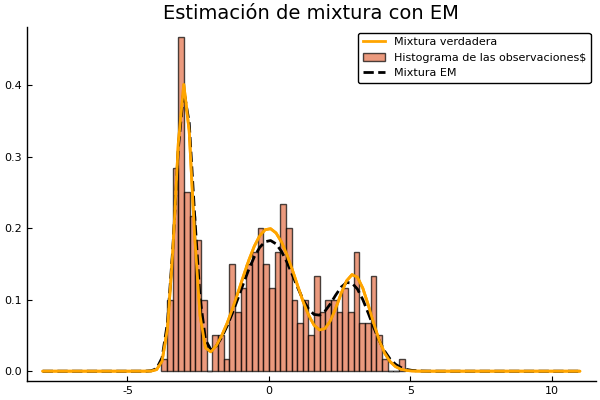

```julia
p
```

#### Ejemplo: Modelos escondidos de Márkov

Consideramos una cadena de Márkov a tiempo discreto $\pmb{Y}=\left\{Y_t\right\}_{t=1}^\infty$ con espacio de estados finito $\left\{ 1, 2,\ldots , d\right\}$ y matriz de transición $P$ $(d\times d)$-dimensional. Suponemos que observamos un proceso $\pmb{X}=\left\{X_t\right\}_{t=1}^\infty$ dependiente del estado de la cadena de Márkov $\pmb{Y}$, el cual no puede ser directamente observado, por lo que decimos que la cadena de Márkov está escondida.

Más precisamente el modelo escondido de Márkov que determinado por

\begin{align*} & \mathbb{P}\left[ Y_t \, | \, Y_1,\ldots , Y_{t-1} \right] = \mathbb{P}\left[ Y_t \, | \, Y_{t-1} \right], \quad t\in\left\{2,3,\ldots\right\} \\ & \mathbb{P}\left[ X_t \, | \, X_1,\ldots , X_{t-1}, Y_1,\ldots , Y_{t-1}, Y_t \right] = \mathbb{P}\left[ X_t \, | \, Y_t \right], \quad t\in\left\{2,3,\ldots\right\} \end{align*}

```julia
μ = [3.0, 0.0]
σ = [1.0,  0.5]
P = [ 0.7 0.3 ; 0.2 0.8 ]
```

```
2×2 Array{Float64,2}:
 0.7  0.3
 0.2  0.8
```

```julia
n = 1000
Y = zeros(Int64, n)
X = zeros(Float64,n)
Y[1] = 1
X[1] = rand(Normal(μ[1],σ[1]))
for i in 2:n
    if rand(Uniform()) < P[Y[i-1],Y[i-1]]
        Y[i] = Y[i-1]
    else
        Y[i] = 3-Y[i-1]
    end
    X[i] = rand(Normal(μ[Y[i]],σ[Y[i]]))
end
```

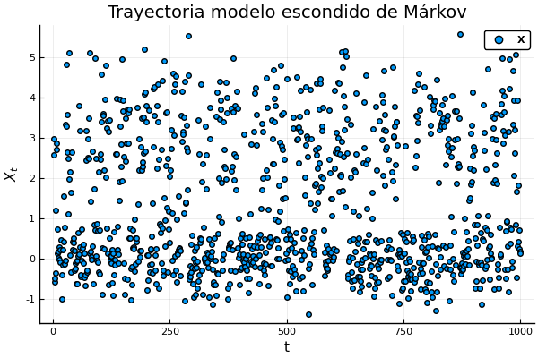

```julia
p
```

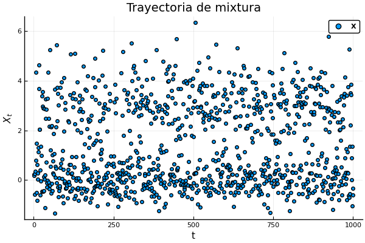

```julia
p
```

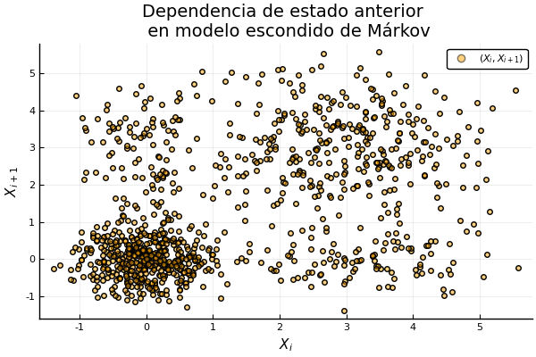

```julia
p
```

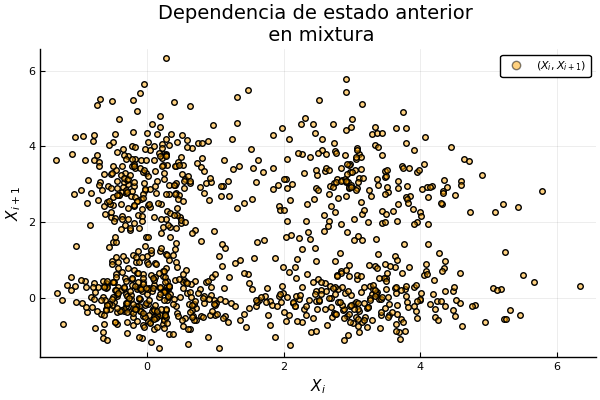

```julia
p
```

Para una muestra de observaciones $X_1,\ldots , X_n$ la función empírica de autocorrelación está dada por $$ \hat{R}(k)=\frac{1}{(n-k)\hat{\sigma}^2_n}\sum_{i=1}^{n-k} (X_i-\hat{\mu}_n)(X_{i+k}-\hat{\mu}_n) $$

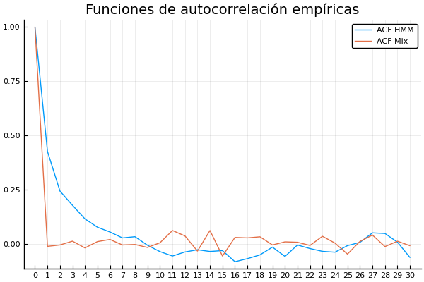

```julia
p
```

Para el algoritmo EM con el modelo escondido de Márkov dado observaciones $\pmb{X}=\left\{X_t\right\}_{t=1}^n$ es natural considerar como datos faltantes la trayectoria no observada de la cadena de Márkov escondida $\pmb{Y}=\left\{Y_t\right\}_{t=1}^n$. Definimos las siguientes variables, cuya observación es equivalente a la de los datos faltantes.

\begin{align*} w(j,t) & = \mathbb{1}\left\{ Y_t = j \right\}, &j\in\left\{1,\ldots , d \right\},\, t\in\left\{1,\ldots , n \right\} \\ v(j,i,t)& = \mathbb{1}\left\{ Y_{t-1} = j,\, Y_t=i \right\}, &j,i\in\left\{1,\ldots , d \right\},\, t\in\left\{1,\ldots , n \right\} \end{align*}

Con $p_1$ una función de probabilidad de masa para la distribución inicial sobre los estados y $f_j$ la densidad de la distribución de emisión $X_t|Y_t=j$. \begin{align*} \log\left(L^c\left( \pmb{x}_{1:n}, \pmb{x}_{1:n} \right)\right) & =\log \left( p_1(y_1)f_{y_1}(x_1) \prod_{t=2}^nP[y_{t-1},y_t]f_{y_t}(x_t) \right) \\ & = \log\left( p_1(y_1) \right) + \sum_{t=2}^n\log \left( P[y_{t-1},y_t] \right)+ \sum_{t=1}^n\log \left( f_{y_t}(x_t) \right) \\ &= \sum_{j=1}^d w(j,1)\log\left( p_1(j) \right) + \sum_{j=1}^d \sum_{i=1}^d \left( \sum_{t=2}^n v(j,i,t) \right)\log \left( P[j,i] \right) \\ & \hphantom{=}+ \sum_{j=1}^d \sum_{t=1}^n w(j,t)\log \left( f_{j}(x_t) \right) \end{align*}

Se sigue que para el algoritmo EM

\begin{align*} Q\left( \pmb{\theta} \, | \, \hat{ \pmb{\theta}}^{(k-1)} \right)=& \sum_{j=1}^d \hat{w}^{(k-1)}(j,1)\log\left( p_1(j) \right) + \sum_{j=1}^d \sum_{i=1}^d \left( \sum_{t=2}^n \hat{v}^{(k-1)}(j,i,t) \right)\log \left( P[j,i] \right) \\ & + \sum_{j=1}^d \sum_{t=1}^n \hat{w}^{(k-1)}(j,t)\log \left( f_{j}(x_t) \right) \end{align*}

con

\begin{align*} \hat{w}^{(k-1)}(j,t) &= \mathbb{P}_{\hat{\pmb{\theta}}^{(k-1)}}\left[ Y_t=j \, | \, \pmb{X}=\pmb{x} \right] \\ \hat{v}^{(k-1)}(j,i,t) &= \mathbb{P}_{\hat{\pmb{\theta}}^{(k-1)}}\left[ Y_{t-1}=j,\, Y_t=i \, | \, \pmb{X}=\pmb{x} \right] \end{align*}

Análogamente al caso del algoritmo EM para mixturas gaussianas, tenemos que

$$ \hat{p}^{(k)}_1(j) = \frac{ \hat{w}^{(k-1)}(j,1) }{\sum_{m=1}^d \hat{w}^{(k-1)}(m,1)} = \hat{w}^{(k-1)}(j,1) $$

y

$$ \hat{P}^{(k)}[j,i] = \frac{\sum_{t=2}^n \hat{v}^{(k-1)}(j,i,t)}{ \sum_{i=1}^d \sum_{t=2}^n \hat{v}^{(k-1)}(j,i,t) } $$

Y si elegimos dsitribuciones de emisión gaussianas podemos utilizar el cálculo del EM para mixturas gaussianas correspondiente para hallar el resto de los argumentos que maximizan $Q$.

Resta discutir el cálculo de las cantidades $\hat{v}(j)=\mathbb{P}_{\theta}\left[ Y_t=j \, | \, \pmb{X}=\pmb{x} \right]$ y $\hat{w}(j,k)=\mathbb{P}_{\theta}\left[ Y_{t-1}=j,\, Y_t=k \, | \, \pmb{X}=\pmb{x} \right]$ para el cual usaremos dos recursión sobre probabilidades, una hacia adelante en el tiempo y otra hacía atrás. A las probabilidades en estás recursiones las llamaremos respectivamente probabilidades hacia adelante (o forward) y probabilidades hacia atrás (o backward) y serán de ayuda para calcular la verosimilitud, $\hat{v}(j)$ y $\hat{w}(j,k)$.

Observemos que

\begin{align*} \mathbb{P}\left[ X_1=x_1,Y_1=y_1,\ldots , X_n=x_n,Y_n=y_n \right]& = \mathbb{P}\left[ Y_1 = y_1 \right] \mathbb{P}\left[ X_1=x_1 \, | \, Y_1 = y_1 \right] \prod_{i=2}^n \mathbb{P}\left[ Y_i = y_i \, | \, Y_{i-1} = y_{i-1} \right]\mathbb{P}\left[ X_i=y_i \, | \, Y_i = y_i \right] \\ & = p_1(y_1)f_{y_1}(x_1) \prod_{i=2}^n P[y_{i-1},y_i]f_{y_i}(x_i) \stackrel{\text{def.}}{=} p(\pmb{x}_{1:n},\pmb{y}_{1:n}) , \end{align*}

que \begin{align*} p(\pmb{x}_{1:i} , y_{i}) \stackrel{\text{def.}}{=} \mathbb{P}\left[X_1 = x_1, \ldots , X_i=x_i,Y_i = y_i\right] = \sum_{y_{i-1}=1}^d p(\pmb{x}_{1:(i-1)} , y_{i-1}) P[y_{i-1},y_i]f_{y_i}(x_i) \end{align*} y que \begin{align*} p(\pmb{x}_{(i+1):n} \, | \, y_{i}) \stackrel{\text{def.}}{=} \mathbb{P}\left[X_{i+1} = x_{i+1}, \ldots , X_n=x_n \, | \, Y_i = y_i\right] = \sum_{y_{i+1}=1}^d f_{y_{i+1}}(x_{i+1}) P[y_i.y_{i+1}] p(\pmb{x}_{(i+2):n} \, | \, y_{i+1}) \end{align*}

Con lo que si tomamos \begin{align*} \pmb{\alpha}_1 &= (\alpha_{1,1},\ldots \alpha_{1,d} ) \stackrel{\text{def.}}{=} \left( p(x_1 , 1), \ldots , p(x_1 , d) \right) \\ & = \left( p_1(1)f_1(x_1), \ldots , p_1(d)f_d(x_1) \right) \end{align*} entonces se satisface \begin{align*} \pmb{\alpha}_i & \stackrel{\text{def.}}{=} \left( p(\pmb{x}_{1:i} , 1),\ldots , p(\pmb{x}_{1:i} , d) \right) \\ &= \left( \sum_{j=1}^d \alpha_{i-1,j} P[j,1]f_1 (x_i) , \ldots , \sum_{j=1}^d \alpha_{i-1,j} P[j,d]f_d (x_i) \right) \end{align*} para $i\in{2,\ldots , n}$.

Por otro lado si tomamos \begin{align*} \pmb{\beta}_1 &= (\beta_{1,1},\ldots \beta_{1,d} ) \stackrel{\text{def.}}{=} \pmb{1}=(1,\ldots,1) \end{align*} entonces se satisface \begin{align*} \pmb{\beta}_i & \stackrel{\text{def.}}{=} \left( p(\pmb{x}_{(i+1):n} \, | \, 1), \ldots , p(\pmb{x}_{(i+1):n} \, | \, d)\right) \\ &= \left( \sum_{j=1}^d f_{1}(x_{i+1}) P[y_i.y_{i+1}] \beta_{i+1,j} , \ldots , \sum_{j=1}^d f_{d}(x_{i+1}) P[y_i.y_{i+1}]\beta_{i+1,j} \right) \end{align*} para $i\in\left\{2,\ldots , n\right\}$.

Tenemos que para $i\in \left\{1,\ldots ,n\right\}$

\begin{align*} \pmb{\alpha}_i \cdot \pmb{\beta}_i = \sum_{j=1}^d p(\pmb{x}_{1:i} , j) p(\pmb{x}_{(i+1):n} \, | \, j) =\mathbb{P}\left[ X_1=x_1,\ldots , X_n=x_n \right]=L(\pmb{X}=\pmb{x}) \end{align*}

obetenemos la verosimilitud $L$.

Para implementar el algoritmo EM obtenemos las siguientes cantidades en términos de las probabilidades forward y backward

\begin{align*} \hat{w}(j,i) &= \mathbb{P}\left[ Y_i=j \, | \, \pmb{X}=\pmb{x} \right] \propto \mathbb{P}\left[ \pmb{X}=\pmb{x} , Y_i=j \right] = p(\pmb{x}_{1:i} , j) p(\pmb{x}_{(i+1):n} \, | \, j) = \alpha_{i}[j] \beta_{i}[j] \end{align*}

y

\begin{align*} \hat{v}(j,k,i) &= \mathbb{P} \left[ Y_{i-1}=j,\, Y_i=k \, | \, \pmb{X}=\pmb{x} \right] \propto \mathbb{P}\left[ \pmb{X}=\pmb{x} , Y_{i-1}=j, Y_i=k \right] \\ & = p(\pmb{x}_{1:(i-1)} , j)P[j,k] f_{k}(x_i) p(\pmb{x}_{(i+1):n} \, | \, j) = \alpha_{i-1}[j] P[j,k] f_{k}(x_i) \beta_{i}[k] \end{align*}

```julia
# Matriz de transición verdadera
P
```

```
2×2 Array{Float64,2}:
 0.7  0.3
 0.2  0.8
```

```julia
# Estimación EM
P_EM[end,:,:]
```

```
2×2 Array{Float64,2}:
 0.741485  0.258515
 0.195761  0.804239
```

```julia
# Vector de medias verdadero
μ
```

```
2-element Array{Float64,1}:
 3.0
 0.0
```

```julia
# Estimación EM
μ_EM[end,:]
```

```
2-element Array{Float64,1}:
  3.003365440543651
 -0.012970181172028803
```

```julia
# Vector de desviaciones estándar verdadero
σ
```

```
2-element Array{Float64,1}:
 1.0
 0.5
```

```julia
# Estimación EM
σ_EM[end,:]
```

```
2-element Array{Float64,1}:
 1.0195910337813316
 0.4887190927409918
```

```julia
p₀_EM[end,:]
```

```
2-element Array{Float64,1}:
 1.0
 0.0
```

#### Trayectoria escondida más probable de Viterbi

Dado un modelo escondido de Márkov con vector de parámetors $\pmb{\theta}$, o $\hat{\pmb{\theta}}$ un estimador de éste. Definimos la trayectoria más probable de $y_i^\star$, $i\in \left\{ 1, \ldots , n\right)$ como

\begin{align*} \pmb{y}^\star_{1:n}=\left( y_1^\star,\ldots , y_d^\star \right) & \stackrel{\text{def.}}{=} \text{argmax}_{\left( y_1, \ldots , y_n\right)} \mathbb{P}_{\pmb{\theta}}\left[ Y_1=y_1 , \ldots , Y_n=y_n \, | \, X_1=x_1,\ldots , X_n = x_n \right] \\ & \stackrel{\text{def.}}{=} \text{argmax}_{\left( y_1, \ldots , y_n\right)} \mathbb{P}_{\pmb{\theta}}\left[ Y_1=y_1, X_1=x_1, , \ldots , Y_n=y_n , X_n = x_n \right] \end{align*}

(en caso de que haya más de una trayectoría más probable simplemente elegimos un elemento del conjumto $\text{argmax}_{\left( y_1, \ldots , y_n\right)} \mathbb{P}_{\pmb{\theta}}\left[ Y_1=y_1 , \ldots , Y_n=y_n \, | \, X_1=x_1,\ldots , X_n = x_n \right]$)

Observemos que si definimos

\begin{align*} \mu_1(y_1) = p_1(y_1)f_{y_1}(x_1) \end{align*}

y

\begin{align*} \mu_i(y_i) = \max_{y_{i-1}} \mu_{i-1}(y_{i-1}) P[y_{i-1},y_i]f_{y_i}(x_i) \end{align*}

Entonces

\begin{align*} M &= \max_{\pmb{y}_{1:n} } = p(\pmb{x}_{1:n},\pmb{y}_{1:n}) = \max_{\pmb{y}_{1:n} } p_1(y_1)f_{y_1}(x_1) \prod_{i=2}^n P[y_{i-1},y_i]f_{y_i}(x_i) \\ & = \max_{\pmb{y}_{1:n} } \mu_1(y_1) \prod_{i=2}^n P[y_{i-1},y_i]f_{y_i}(x_i) = \max_{\pmb{y}_{1:n} } \mu_1(y_1) P[y_1,y_2]f_{y_2}(x_2) \prod_{i=3}^n P[y_{i-1},y_i]f_{y_i}(x_i) \\ & = \max_{\pmb{y}_{2:n} } \left( \max_{\pmb{y}_1 } \mu_1(y_1) P[y_1,y_2]f_{y_2}(x_2) \right) \prod_{i=3}^n P[y_{i-1},y_i]f_{y_i}(x_i) = \max_{\pmb{y}_{2:n} } \mu_2(y_2) \prod_{i=3}^n P[y_{i-1},y_i]f_{y_i}(x_i) \\ &= \max_{\pmb{y}_n } \mu_n(y_n) \end{align*}

Para encontrar una trayectoria más probable $\pmb{y}^\star$ simplemente formamos el vector $\pmb{y}^\star$ obtenido por tomar el $\text{argmax}$ en la recursión que define $\mu_i$ con $i\in\left\{1,\ldots , n\right\}$. a la trayectoria obtenida de tal forma la llamamos la trayectoria de Viterbi

### Algoritmo de Viterbi

1) Tome $y^\star_n \in \text{argmax}_{y_n} \mu_n(y_n) $

2) Para $i$ desde $n-1$ hasta $1$

2.1) $y^\star_i \in \text{argmax}_{y_i } \mu_i(y_i) P[y_i,y^\star_{i+1}]f_{y^\star_{i+1}}(x_{i+1}) $

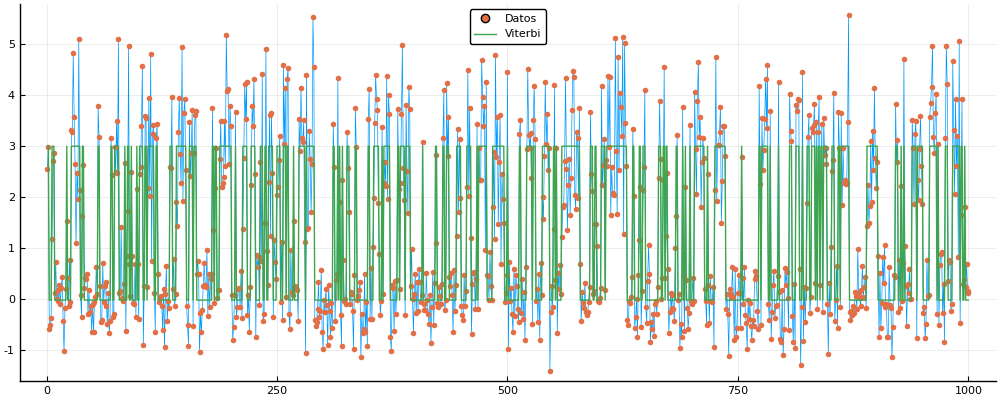

```julia
p
```

```julia
# Cambiemos los parámetros
μ = [3.0, 0.0]
σ = [1.0,  0.5]
P = [ 0.9 0.1 ; 0.05 0.95 ]
```

```
2×2 Array{Float64,2}:
 0.9   0.1
 0.05  0.95
```

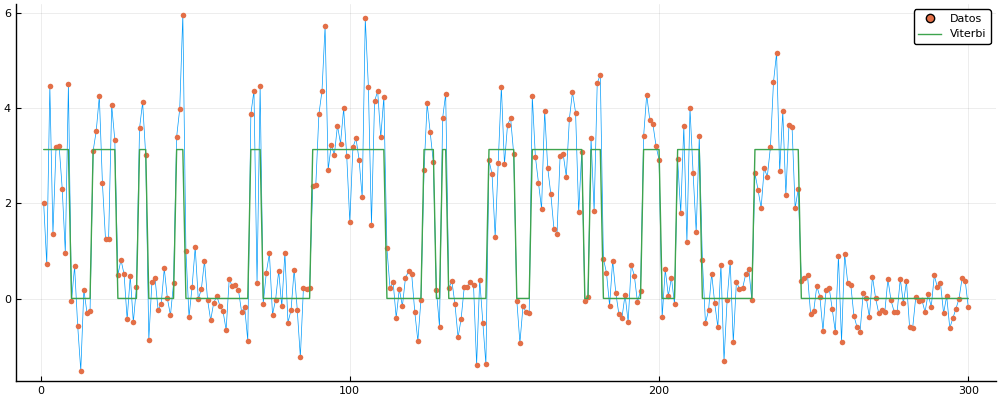

```julia
p=plot(X, linewidth=0.5,label="")
scatter!(X, markerstrokewidth=0, label="Datos")
plot!(μ_EM[end,:][v_EM],label="Viterbi")
plot!(size=(1000,400))
```

```julia
# Datos de terremotos
earthquake_ts = CSV.read("earthquake_ts_1900_2020.csv", DataFrame)
```

|  | time String | latitude Float64 | longitude Float64 | depth Float64? | mag Float64 | magType String | nst Int64? |
| --- | --- | --- | --- | --- | --- | --- | --- |
| 1 | 2020-10-30T11:51:27.365Z | 37.9125 | 26.779 | 21.0 | 7.0 | mww | *missing* |
| 2 | 2020-10-19T20:54:39.006Z | 54.5957 | -159.622 | 29.13 | 7.6 | mww | *missing* |
| 3 | 2020-07-22T06:12:44.810Z | 55.0715 | -158.596 | 28.0 | 7.8 | mww | *missing* |
| 4 | 2020-07-17T02:50:22.178Z | -7.836 | 147.77 | 73.0 | 7.0 | mww | *missing* |
| 5 | 2020-06-23T15:29:04.350Z | 15.8861 | -96.0077 | 20.0 | 7.4 | mww | *missing* |
| 6 | 2020-06-18T12:49:53.844Z | -33.2927 | -177.857 | 10.0 | 7.4 | mww | *missing* |
| 7 | 2020-03-25T02:49:21.160Z | 48.9638 | 157.696 | 57.8 | 7.5 | mww | *missing* |
| 8 | 2020-02-13T10:33:44.406Z | 45.6161 | 148.959 | 143.0 | 7.0 | mww | *missing* |
| 9 | 2020-01-28T19:10:24.918Z | 19.4193 | -78.756 | 14.86 | 7.7 | mww | *missing* |
| 10 | 2019-11-14T16:17:40.578Z | 1.6213 | 126.416 | 33.0 | 7.1 | mww | *missing* |
| 11 | 2019-07-14T09:10:51.523Z | -0.5858 | 128.034 | 18.98 | 7.2 | mww | *missing* |
| 12 | 2019-07-06T03:19:53.040Z | 35.7695 | -117.599 | 8.0 | 7.1 | mw | 77 |
| 13 | 2019-06-24T02:53:39.830Z | -6.4078 | 129.169 | 212.0 | 7.3 | mww | *missing* |
| 14 | 2019-06-15T22:55:04.130Z | -30.6441 | -178.1 | 46.0 | 7.3 | mww | *missing* |
| 15 | 2019-05-26T07:41:15.073Z | -5.8119 | -75.2697 | 122.57 | 8.0 | mww | *missing* |
| 16 | 2019-05-14T12:58:25.939Z | -4.051 | 152.597 | 10.0 | 7.6 | mww | *missing* |
| 17 | 2019-05-06T21:19:37.983Z | -6.9746 | 146.449 | 146.0 | 7.1 | mww | *missing* |
| 18 | 2019-03-01T08:50:42.591Z | -14.7131 | -70.1546 | 267.0 | 7.0 | mww | *missing* |
| 19 | 2019-02-22T10:17:23.770Z | -2.1862 | -77.0505 | 145.0 | 7.5 | mww | *missing* |
| 20 | 2018-12-29T03:39:09.740Z | 5.8983 | 126.921 | 60.21 | 7.0 | mww | *missing* |
| 21 | 2018-12-20T17:01:55.150Z | 55.0999 | 164.699 | 16.56 | 7.3 | mww | *missing* |
| 22 | 2018-12-11T02:26:29.420Z | -58.5446 | -26.3856 | 133.0 | 7.1 | mww | *missing* |
| 23 | 2018-12-05T04:18:08.420Z | -21.9496 | 169.427 | 10.0 | 7.5 | mww | *missing* |
| 24 | 2018-11-30T17:29:29.330Z | 61.3464 | -149.955 | 46.7 | 7.1 | mw | *missing* |
| 25 | 2018-10-10T20:48:20.100Z | -5.7012 | 151.205 | 39.0 | 7.0 | mww | *missing* |
| 26 | 2018-09-28T10:02:45.250Z | -0.2559 | 119.846 | 20.0 | 7.5 | mww | *missing* |
| 27 | 2018-09-06T15:49:18.710Z | -18.4743 | 179.35 | 670.81 | 7.9 | mww | *missing* |
| 28 | 2018-08-29T03:51:56.100Z | -22.0295 | 170.126 | 21.43 | 7.1 | mww | *missing* |
| 29 | 2018-08-24T09:04:08.250Z | -11.0355 | -70.8284 | 630.0 | 7.1 | mww | *missing* |
| 30 | 2018-08-21T21:31:47.600Z | 10.7731 | -62.9019 | 146.82 | 7.3 | mww | *missing* |
| ⋮ | ⋮ | ⋮ | ⋮ | ⋮ | ⋮ | ⋮ | ⋮ |

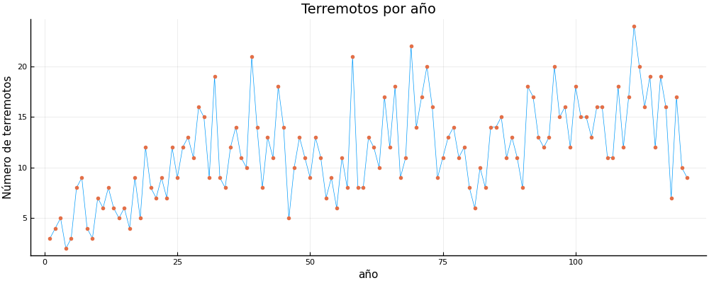

```julia
p
```

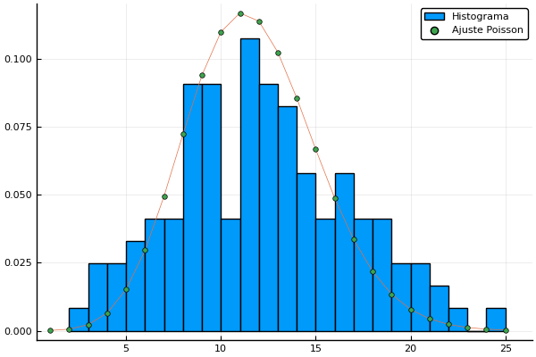

```julia
p
```

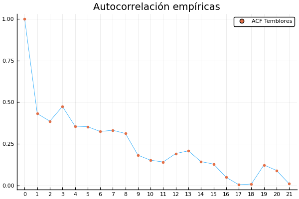

```julia
p
```

```julia
m= 100
p₀_EM = zeros(m+1,3)
P_EM = zeros(m+1,3,3)
λ_EM = zeros(m+1,3)
λ_EM[1,:] = [5.0,12.0,15.0]
p₀_EM[1,:] = [0.9, 0.05, 0.05]
P_EM[1,:,:] = [0.97 0.03 0.0; 0.0 0.95 0.05; 0.0 0.05 0.95];
```

```julia
for i in 2:(m+1)
    tmp_log_forw = forward_probs_poi_logsumexp(year_freq,p₀_EM[i-1,:],P_EM[i-1,:,:],λ_EM[i-1,:])
    tmp_log_backw = backward_probs_poi_logsumexp(year_freq,P_EM[i-1,:,:],λ_EM[i-1,:])
    tmp_hat_u = u_E_step_log( tmp_log_forw, tmp_log_backw)
    tmp_hat_v = v_E_step_poi_log( year_freq,P_EM[i-1,:,:],λ_EM[i-1,:],tmp_log_forw, tmp_log_backw)
    p₀_EM[i,:] = tmp_hat_u[1,:]
    P_EM[i,:,:] = P_from_v(tmp_hat_v)
    for j in 1:2
        n_hat_u_i_j = sum( tmp_hat_u[:,j] )
        λ_EM[i,j] = sum( tmp_hat_u[:,j] .* year_freq  )/n_hat_u_i_j
    end
end
```

[output not shown]

```julia
P_EM[1:10,:,:]
```

```
10×3×3 Array{Float64,3}:
[:, :, 1] =
   0.97        0.0    0.0
   0.945321    0.0    0.0
   0.94645     0.0  NaN
 NaN         NaN    NaN
   0.0         0.0    0.0
   0.0         0.0    0.0
   0.0         0.0    0.0
   0.0         0.0    0.0
   0.0         0.0    0.0
   0.0         0.0    0.0

[:, :, 2] =
   0.03         0.95        0.05
   0.0546792    0.960314    0.0590545
   0.0535498    1.0       NaN
 NaN          NaN         NaN
   0.0          0.0         0.0
   0.0          0.0         0.0
   0.0          0.0         0.0
   0.0          0.0         0.0
   0.0          0.0         0.0
   0.0          0.0         0.0

[:, :, 3] =
   0.0    0.05         0.95
   0.0    0.0396861    0.940945
   0.0    0.0        NaN
 NaN    NaN          NaN
   0.0    0.0          0.0
   0.0    0.0          0.0
   0.0    0.0          0.0
   0.0    0.0          0.0
   0.0    0.0          0.0
   0.0    0.0          0.0
```

```julia
m= 1000
p₀_EM = zeros(m+1,2)
P_EM = zeros(m+1,2,2)
λ_EM = zeros(m+1,2)
λ_EM[1,:] = [3.0,19.0]
p₀_EM[1,:] = [0.9, 0.1]
P_EM[1,:,:] = [0.5 0.5; 0.5 0.5];
```

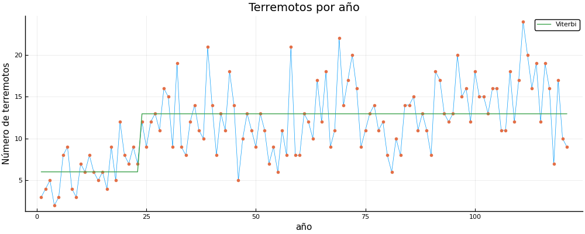

```julia
p
```

[figure not shown]

```julia
p=plot(year_freq[24:end], linewidth=0.5,label="")
scatter!(year_freq[24:end], markerstrokewidth=0, label="")
plot!(size=(1000,400))
xlabel!("año")
ylabel!("Número de terremotos")
title!("Terremotos por año")
```

```julia
# Estimación EM
λ_EM[end,:]
```

```
2-element Array{Float64,1}:
 10.817794130344431
 15.172741937678795
```

```julia
P_EM[end,:,:]
```

```
2×2 Array{Float64,2}:
 0.909479   0.0905213
 0.0937122  0.906288
```

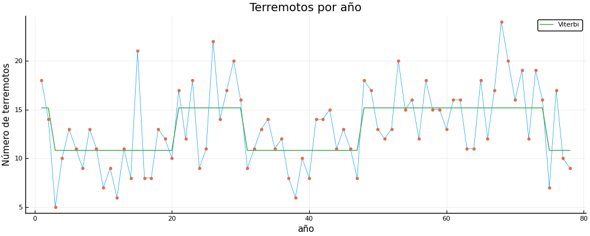

```julia
p
```